# 关于汽车价格影响因素的数据分析——数据科学工具期末作业

目前以我国的汽车市场来看，销售价格可以从3、4万一直跨越到百万、千万级别，之间的差距巨大。汽车产品制定价格，其实是一项比较复杂，而且很系统的过程。需要主机厂的采购，产品，工艺，营销等等部门的平衡，才可能完成这项工作。各类汽车产品针对的是汽车市场上不同的人群，它们也担负着各自厂商的不同目标——维持着企业生存或是扩大市场占有率等。同时汽车产品的成本，如制造、管理、营销、储存运输的成本、研发设计成本的不同，各个品牌上的差距及营销手段等等都与汽车价格有相当大的关联。但回归到汽车的性能本身，汽车的价格与汽车性能和指标因素之间又有着多大的关联呢？

本报告以SPSS自带原数据集car_sales_unprepared为依据，试图通过数据集的清洗，简单描述统计分析，数据建模，数据可视化等方式探索出汽车价格的影响因素，以下为报告全内容：

### 描述统计分析

先导入常用包：

```python
import pandas as pd
import numpy as np
import matplotlib.pyplot as plt
import seaborn as sns
%matplotlib inline
```

```python
df= pd.read_csv( "D:/Learning materials/tools-for-data-science-course/作业/car_sales_unprepared.csv",encoding='gbk')
df.head(10)
```

|  | 制造商 | 模型 | 销售 | 转售 | 类型 | 价格 | engine_s | 马力 | 轴距 | 宽度 | 长度 | curb_wgt | fuel_cap | mpg |
| --- | --- | --- | --- | --- | --- | --- | --- | --- | --- | --- | --- | --- | --- | --- |
| 0 | Acura | Integra | 16.919 | 16.36 | 0 | 21.5 | 1.8 | 140 | 101.2 | 67.3 | 172.4 | 2.639 | 13.2 | 28 |
| 1 | Acura | TL | 39.384 | 19.875 | 0 | 28.4 | 3.2 | 225 | 108.1 | 70.3 | 192.9 | 3.517 | 17.2 | 25 |
| 2 | Acura | CL | 14.114 | 18.225 | 0 |  | 3.2 | 225 | 106.9 | 70.6 | 192 | 3.47 | 17.2 | 26 |
| 3 | Acura | RL | 8.588 | 29.725 | 0 | 42 | 3.5 | 210 | 114.6 | 71.4 | 196.6 | 3.85 | 18 | 22 |
| 4 | Audi | A4 | 20.397 | 22.255 | 0 | 23.99 | 1.8 | 150 | 102.6 | 68.2 | 178 | 2.998 | 16.4 | 27 |
| 5 | Audi | A6 | 18.780 | 23.555 | 0 | 33.95 | 2.8 | 200 | 108.7 | 76.1 | 192 | 3.561 | 18.5 | 22 |
| 6 | Audi | A8 | 1.380 | 39 | 0 | 62 | 4.2 | 310 | 113 | 74 | 198.2 | 3.902 | 23.7 | 21 |
| 7 | BMW | 323i | 19.747 |  | 0 | 26.99 | 2.5 | 170 | 107.3 | 68.4 | 176 | 3.179 | 16.6 | 26.1 |
| 8 | BMW | 328i | 9.231 | 28.675 | 0 | 33.4 | 2.8 | 193 | 107.3 | 68.5 | 176 | 3.197 | 16.6 | 24 |
| 9 | BMW | 528i | 17.527 | 36.125 | 0 | 38.9 | 2.8 | 193 | 111.4 | 70.9 | 188 | 3.472 | 18.5 | 24.8 |

计算行数和列数，并检查每个列的数据类型：

```python
df.shape
```

```
(157, 14)
```

即共有157个样本个数，14个变量

```python
df.dtypes
```

```
制造商          object
模型           object
销售          float64
转售           object
类型            int64
价格           object
engine_s     object
马力           object
轴距           object
宽度           object
长度           object
curb_wgt     object
fuel_cap     object
mpg          object
dtype: object
```

经观察得：该数据集包含价格、销售估计值、订价以及各种品牌和型号的车辆的物理规格。为探索汽车各项性能和指标与价格的关系，可以以价格为预测变量，以其他变量为解释变量进行探索分析。

检查是否有缺失值：

```python
df.info()
```

```
<class 'pandas.core.frame.DataFrame'>
RangeIndex: 157 entries, 0 to 156
Data columns (total 14 columns):
 #   Column    Non-Null Count  Dtype
---  ------    --------------  -----
 0   制造商       157 non-null    object
 1   模型        157 non-null    object
 2   销售        157 non-null    float64
 3   转售        157 non-null    object
 4   类型        157 non-null    int64
 5   价格        157 non-null    object
 6   engine_s  157 non-null    object
 7   马力        157 non-null    object
 8   轴距        157 non-null    object
 9   宽度        157 non-null    object
 10  长度        157 non-null    object
 11  curb_wgt  157 non-null    object
 12  fuel_cap  157 non-null    object
 13  mpg       157 non-null    object
dtypes: float64(1), int64(1), object(12)
memory usage: 17.3+ KB
```

再检查是否有重复值：

```python
df.duplicated()
```

```
0      False
1      False
2      False
3      False
4      False
       ...
152    False
153    False
154    False
155    False
156    False
Length: 157, dtype: bool
```

```python
#综合统计分析：
df.describe(include='all')
```

|  | 制造商 | 模型 | 销售 | 转售 | 类型 | 价格 | engine_s | 马力 | 轴距 | 宽度 | 长度 | curb_wgt | fuel_cap | mpg |
| --- | --- | --- | --- | --- | --- | --- | --- | --- | --- | --- | --- | --- | --- | --- |
| count | 157 | 157 | 157.000000 | 157 | 157.000000 | 157 | 157 | 157 | 157 | 157 | 157 | 157 | 157 | 157 |
| unique | 30 | 156 | NaN | 118 | NaN | 153 | 32 | 67 | 89 | 79 | 128 | 148 | 56 | 23 |
| top | Ford | Neon | NaN |  | NaN |  | 2 | 150 | 112.2 | 66.7 | 186.3 | 2.769 | 18.5 | 25 |
| freq | 11 | 2 | NaN | 36 | NaN | 2 | 17 | 9 | 8 | 6 | 4 | 3 | 14 | 22 |
| mean | NaN | NaN | 52.998076 | NaN | 0.261146 | NaN | NaN | NaN | NaN | NaN | NaN | NaN | NaN | NaN |
| std | NaN | NaN | 68.029422 | NaN | 0.440665 | NaN | NaN | NaN | NaN | NaN | NaN | NaN | NaN | NaN |
| min | NaN | NaN | 0.110000 | NaN | 0.000000 | NaN | NaN | NaN | NaN | NaN | NaN | NaN | NaN | NaN |
| 25% | NaN | NaN | 14.114000 | NaN | 0.000000 | NaN | NaN | NaN | NaN | NaN | NaN | NaN | NaN | NaN |
| 50% | NaN | NaN | 29.450000 | NaN | 0.000000 | NaN | NaN | NaN | NaN | NaN | NaN | NaN | NaN | NaN |
| 75% | NaN | NaN | 67.956000 | NaN | 1.000000 | NaN | NaN | NaN | NaN | NaN | NaN | NaN | NaN | NaN |
| max | NaN | NaN | 540.561000 | NaN | 1.000000 | NaN | NaN | NaN | NaN | NaN | NaN | NaN | NaN | NaN |

### 数据建模&可视化分析

```python
#设置字体
import matplotlib as mpl
mpl.rcParams['font.sans-serif'] = ['KaiTi']
mpl.rcParams['font.serif'] = ['KaiTi']
```

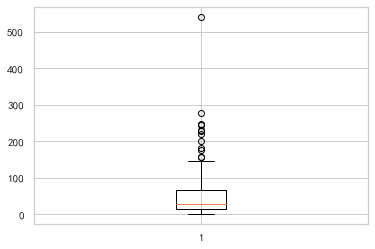

```python
fig=plt.figure()
ax = fig.add_subplot(1,1,1)
ax.boxplot(df['销售'])
plt.show()
```

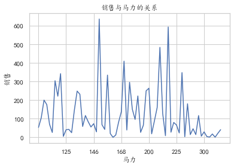

```python
#销售与马力的关系
var = df.groupby('马力').销售.sum()
fig = plt.figure()
ax1 = fig.add_subplot(1,1,1)
ax1.set_xlabel('马力')
ax1.set_ylabel('销售')
ax1.set_title("销售与马力的关系")
var.plot(kind='line')
```

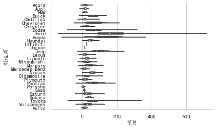

```python
#比较不同品牌制造商的销售
import seaborn as sns
sns.violinplot(df['销售'], df['制造商'])
sns.despine()
```